# 506group

yifxiang

12/3/2017

# Zero-inflated Poisson model

## Motivation

First let’s recall poisson regression model:

Y|X ~ Poisson(exp{X$\beta$})

This model will not be able to deal with some situations we often see in count data as zero-inflation:

There are many more zeros than would be predicted by a Poisson model. A mild amount of zero inflation can be handled by the negative binomial model. However, a large amount will result in a poor fit, especially if the distribution becomes bimodal.

## Model Introduction

To handle this type of data we will fit a mixture model:
$$Yi=\left\{
\begin{aligned}
& Xi &with~~p\\
& 0 &with~~1-p
\end{aligned}
\right.$$

Here Xi is some distribution on the integers, most commonly Poisson in our model. According to this expression, we can also regard Yi as a product of a Poisson variable and a Bernoulli variable.

## Simple Derivation

According to the expression above, we can see zero-inflated poisson model is a kind of latent variable model. We suppose there is some sequence of unobserved Zi~Bernoulli(fi), and that Yi = Xi*Zi.

Thus computing the likelihood P(Y) = P(Y1, … ,Yn) is intractible because it requires marginalizing over all $2^{n}$ possible values of Z. Hence, we must use a different strategy to obtain the MLE:

We can approximately maximize the likelihood using the EM algorithm. Since it is complicated, we just explain some key ideas as a simple derivation:

Zi ~ Bernoulli($\phi$)

Xi ~ Poisson($\lambda$)

Yi = XiZi

The conditional expectation of Zi given Yi is:

P(Zi = 1 | Yi > 0) = 1

P(Zi = 1 | Yi = 0) = $\frac{P(Yi=0,Zi=1)}{P(Yi=0)}$ = $\frac{\phi e^{-\lambda}}{(1-\phi)+\phi e^{-\lambda}}$ =: $\omega(\phi,\lambda)$

The complete log-likelihood is:

Log P(Y,Z) = $\sum_{i}(1-Zi)log[(1-\phi)1(Yi=0)] + Zi[log\phi+logf(yi)]$

Taking E(Z|X,$\phi0$,$\lambda0$), we get:

Q(Y;$\phi$, $\lambda$) = $\sum_{Yi>0}[log\phi+logf(Yi)]+\sum_{Yi=0}[1-\omega(\phi0,\lambda0)]log(1-\phi)+\omega(\phi0,\lambda0)[log(\phi)-\lambda]$

We maximize Q(Y) to get a new estimate $\phi0$, and we iterate.

## Fitting Zero-inflated model in R

### Description of the data

This data comes from a study of nesting horseshoe crabs (J. Brockmann, Ethology,102: 121, 1996).

Each female horseshoe crab in the study had a male crab attached to her in her nest. The study investigated factors that affect whether the female crab had any other males, called satellites, residing nearby her. The response outcome for each female crab is her number of satellites.

The explanatory variables thought possibly to affect this was the female crabs shell width and weight (continuous variables). Moreover, the color and type of spine (catagorical variables) are also thought possible as predictors.

## Examples

### R

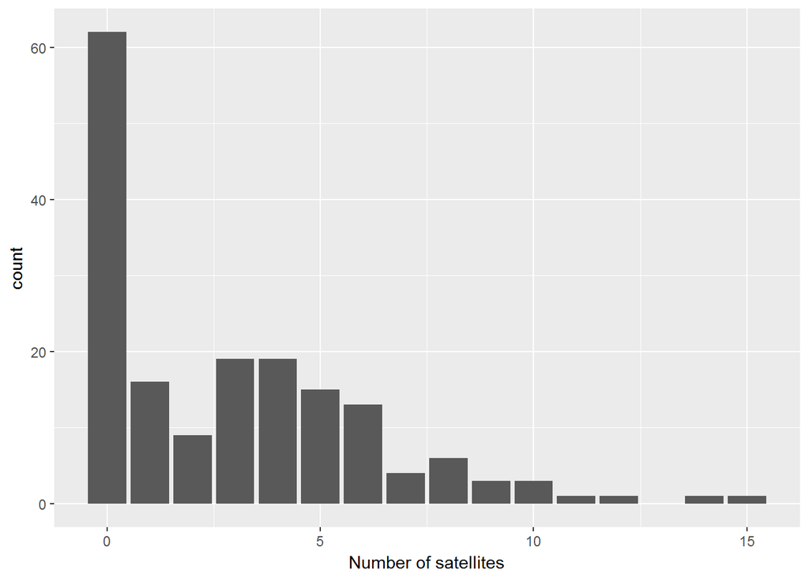

```r
crabs = read.table('http://www.stat.ufl.edu/~aa/glm/data/Crabs.dat', header=T)
save(crabs, file='crabs.RData')
load('crabs.RData')
ggplot(crabs, aes(x=y)) + stat_count() + xlab("Number of satellites")
```

We can see there are many observations with value 0, which is appropriate to apply zero-inflated model here.

To fit zero-inflated poisson model in R, we can use function pscl::zeroinfl()

```r
fit = zeroinfl(y ~ weight+width|color+spine, crabs)
summary(fit)
```

```
##
## Call:
## zeroinfl(formula = y ~ weight + width | color + spine, data = crabs)
##
## Pearson residuals:
##     Min      1Q  Median      3Q     Max
## -1.6349 -0.9258 -0.3129  0.6313  4.3622
##
## Count model coefficients (poisson with log link):
##             Estimate Std. Error z value Pr(>|z|)
## (Intercept)  2.55738    1.01692   2.515  0.01191 *
## weight       0.47758    0.18395   2.596  0.00943 **
## width       -0.08580    0.05331  -1.609  0.10752
##
## Zero-inflation model coefficients (binomial with logit link):
##             Estimate Std. Error z value Pr(>|z|)
## (Intercept)  -2.1164     0.6699  -3.159 0.001582 **
## color         0.8146     0.2330   3.496 0.000472 ***
## spine        -0.2202     0.2258  -0.975 0.329484
## ---
## Signif. codes:  0 '***' 0.001 '**' 0.01 '*' 0.05 '.' 0.1 ' ' 1
##
## Number of iterations in BFGS optimization: 11
## Log-likelihood: -370.1 on 6 Df
```

We found that only weight and color are significant in this model. We can make some plots to confirm this result:

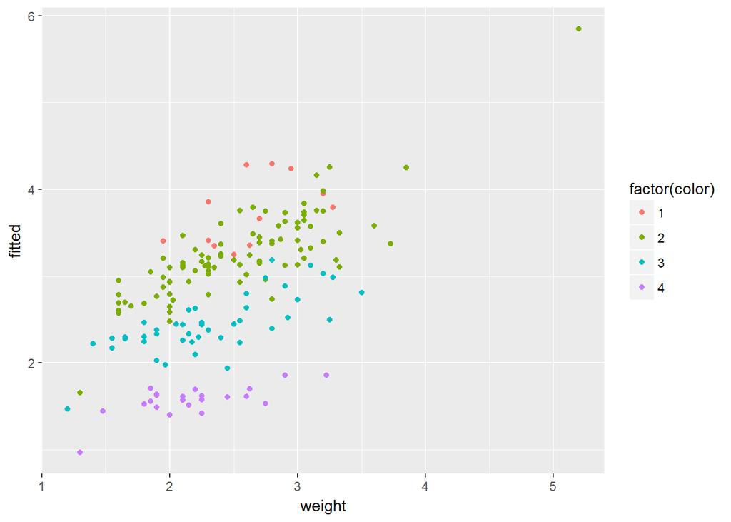

```r
df = data.frame(weight=crabs$weight, color=crabs$color, fitted=fitted(fit))
ggplot(df, aes(x=weight, y=fitted, color=factor(color))) + geom_point()
```

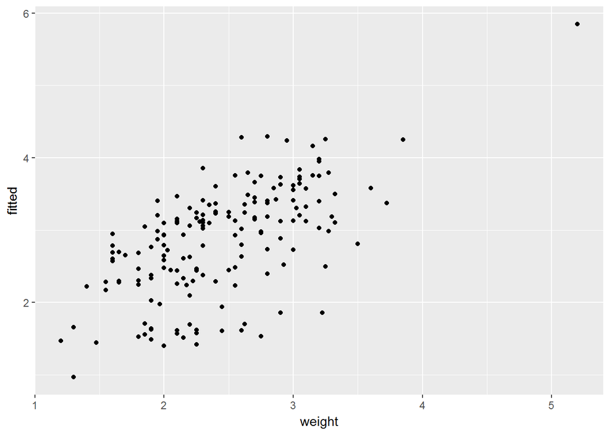

```r
df2 = data.frame(weight=crabs$weight, fitted=fitted(fit))
ggplot(df2, aes(x=weight, y=fitted)) + geom_point()
```

It’s easy to see that there’s an obvious positive correlation between number of satellites and weight. And different colors have different regression lines (nearly parallel).

### STATA

#### Description of the data

We will use the variables **y**, **color**, and **spine** in our model. Let¡¯s look at the data.

```r
. insheet using Crabs.txt, clear delimiter(";")
(7 vars, 173 obs)

. drop n

. list in 1/10
```

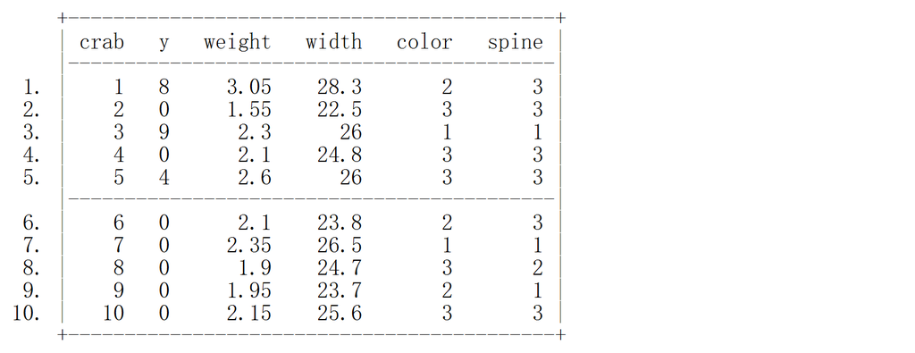

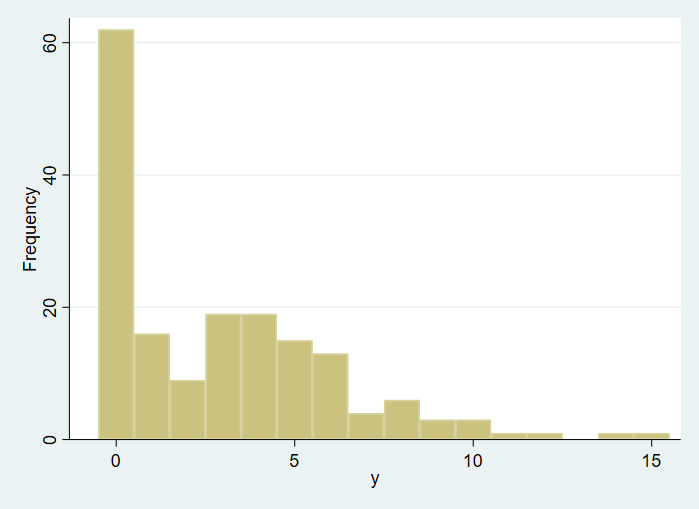

```r
. histogram y, discrete freq
(start=0, width=1)
```

There are many 0s in **y**.

```r
. tab1 color spine
```

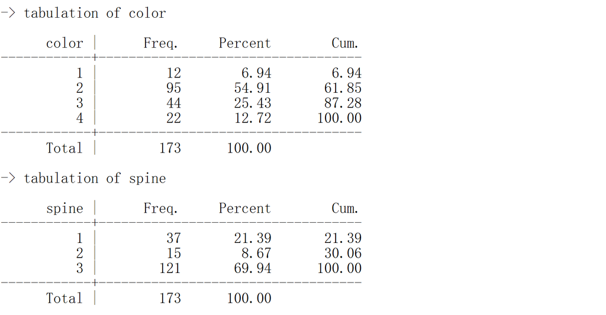

#### Zero-inflated Poisson regression

We will run the **zip** command with **weight** and **width** as predictors of the **y**, **color** and **spine** as the predictor of the excess zeros.

```r
. zip y weight width, inflate(color spine)
```

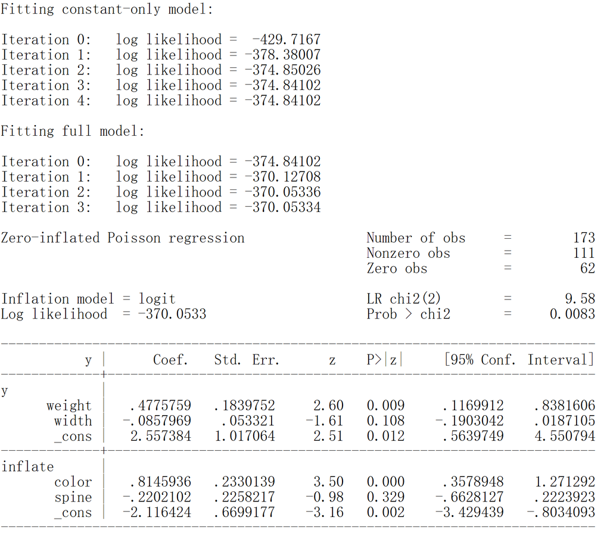

Next, we have included the **vuong** option which provides a test of the zero-inflated model versus the standard poisson model.

```r
. zip y weight width, inflate(color spine) vuong
```

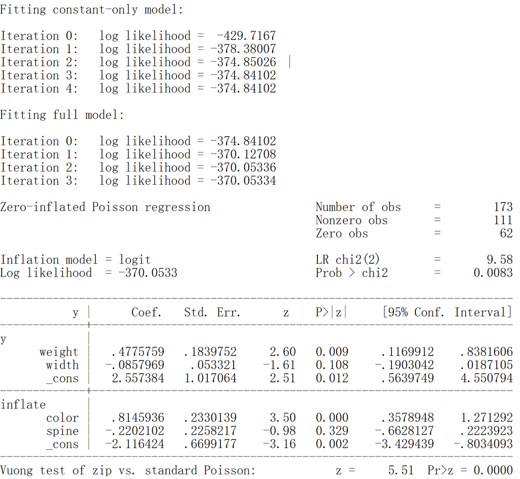

The output looks very much like the output from an OLS regression:

- Begins with the iteration log giving the values of the log likelihoods starting with a model that has no predictors. The last value in the log is the final value of the log likelihood for the full model and is repeated below.
- Next comes the header information. On the right-hand side the number of observations used , number of nonzero observations are given along with the likelihood ratio chi-squared. This compares the full model to a model without count predictors, giving a difference of two degrees of freedom. This is followed by the p-value for the chi-square. The model, as a whole, is statistically significant.
- Below the header you will find the Poisson regression coefficients for each of the count predicting variables along with standard errors, z-scores, p-values and 95% confidence intervals for the coefficients.
- Following these are logit coefficients for the variable predicting excess zeros along with its standard errors, z-scores, p-values and confidence intervals.
- Below the various coefficients you will find the results of the Vuong test. The Vuong test compares the zero-inflated model with an ordinary poisson regression model. A significant z-test indicates that the zero-inflated model is better.
- Cameron and Trivedi (2009) recommend robust standard errors for poisson models. We will rerun the model with the **vce(robust)** option. We did not include this option in the second model because **robust** and **vuong** options cannot be used in the same model.

```r
. zip y weight width, inflate(color spine) vce(robust)
```

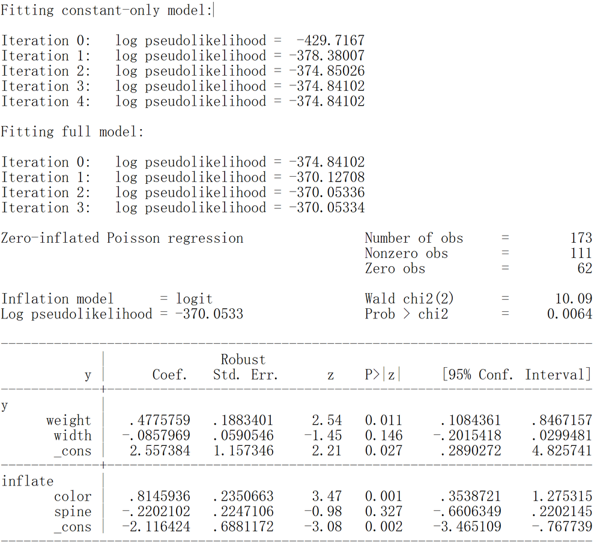

Now we can move on to the specifics of the individual results.

```r
. margins, at(color=(1(1)4) spine=(1(1)3)) vsquish
```

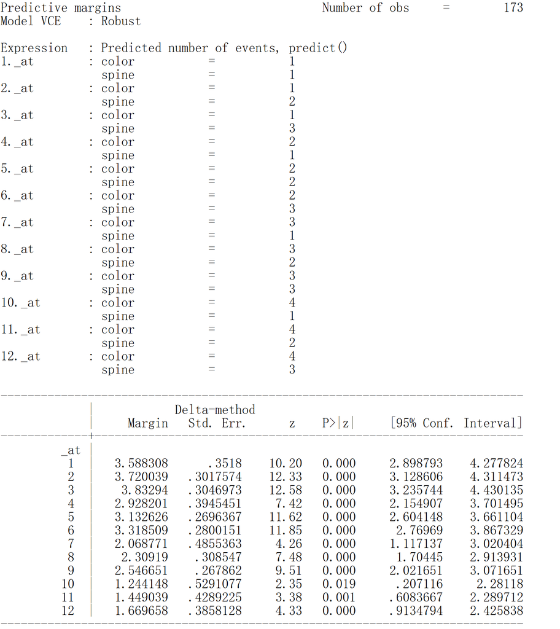

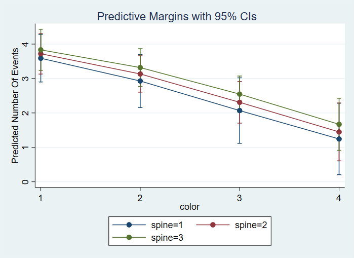

```r
. marginsplot
```

### Python

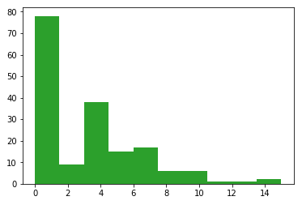

```python
from __future__ import division
import seaborn as sns
from matplotlib import pyplot as plt
import pandas as pd
import numpy as np
from scipy import stats
import statsmodels.api as sm
import statsmodels.miscmodels.count as smm
import pandas as pd
from matplotlib import pyplot as plt
Crabs_datanew = pd.read_csv('C:/Users/Teerth/Downloads/Crabs.dat', sep = '\s+', header = None, skiprows = 1)
plt.hist(Crabs_datanew[1])
#plt.show()
```

So, we can see that there are several values that are occur as 0 in the response variable. We need to apply a Zero-inflated poisson regression to understand which variables can explain the large amount of 0s in the response. We can conduct this regression by using the Maximum Likelihood Estimator for Zero-inflated Poisson. This can be found using the PoissonZiGMLE function in the statsmodels package, and then use this MLE to fit the data.

```python
import pandas as pd
import statsmodels.miscmodels.count as smm
Crabs_datanew = pd.read_csv('C:/Users/Teerth/Downloads/Crabs.dat', sep = '\s+', header = None, skiprows = 1)
X1 = Crabs_datanew[[2,3,4,5]]
MLE = smm.PoissonZiGMLE(Crabs_datanew[1], X1)
ZiP_model = MLE.fit()
ZiP_model.summary()
```

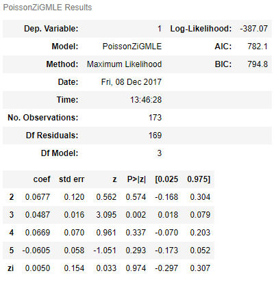